# Barplots and Histograms Assignment Solutions

Mike LeVan

2025-03-10

# Barplots and Histograms Assignment Solutions

## Overview

In this assignment, you will be working with a small dataset and using R to create basic bar plots and histograms. This exercise will help you get familiar with data visualization techniques, which are essential for data analysis and interpretation.

## Skills Checked

1. **Load the Dataset**: Load the provided dataset into R.
2. **Bar Plot**: Create a bar plot to visualize the number of students enrolled in each course.
3. **Histogram**: Create a histogram to visualize the distribution of the number of students across different courses.

## Instructions

For each of the following datasets, please complete the following tasks:

1. **Load the Dataset**
   - Make sure you have the `readr` package installed.
   - Use the `read_csv` function to load the dataset from the provided CSV file.
   - Store the dataset in a variable called `courses_data`.
2. **Create a Bar Plot**
   - Use the `barplot` function to create a bar plot of the number of students enrolled in each course.
   - Label the x-axis as “Courses” and the y-axis as “Number of Students”.
   - Add a title to the plot: “Number of Students Enrolled in Each Course”.
3. **Create a Histogram**
   - Use the `hist` function to create a histogram of the number of students across different courses.
   - Label the x-axis as “Number of Students” and the y-axis as “Frequency”.
   - Add a title to the plot: “Distribution of Number of Students Across Courses”.

## Dataset 1

You will be using a dataset that contains information about the number of students enrolled in different courses at a university. Copy the following dataset into a CSV file named `courses.csv` and upload it to your working directory.

| Course | Number of Students |
| --- | --- |
| Mathematics | 45 |
| Physics | 30 |
| Chemistry | 25 |
| Biology | 50 |
| Computer_Science | 40 |
| History | 35 |
| English | 20 |
| Economics | 30 |

## Instructions

1. **Load the Dataset**
   - Make sure you have the `readr` package installed.
   - Use the `read_csv` function to load the dataset from the provided CSV file.
   - Store the dataset in a variable called `courses_data`.

```r
   # Load the dataset
   courses_data <- read_csv("./courses.csv")
```

2. **Create a Bar Plot**
   - Use the `ggplot` function to create a bar plot of the number of students enrolled in each course.
   - Label the x-axis as “Courses” and the y-axis as “Number of Students”.
   - Add a title to the plot: “Number of Students Enrolled in Each Course”.

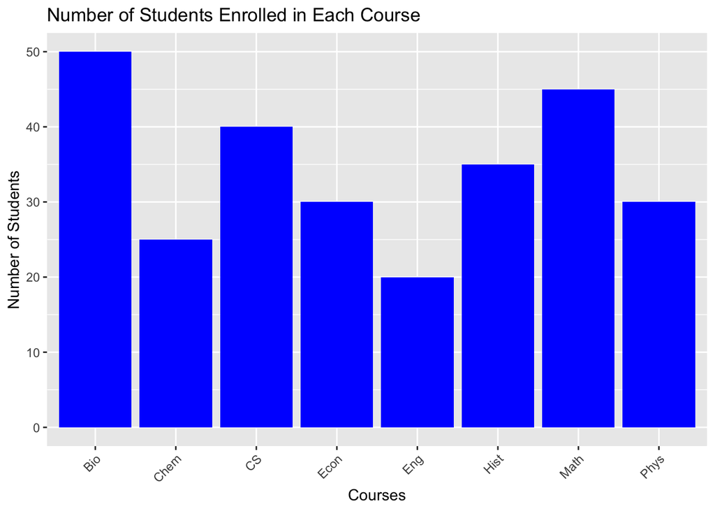

```r
   # Create a bar plot
# Create a bar plot using ggplot2
ggplot(courses_data, aes(x = Course, y = Students)) +
  geom_bar(stat = "identity", fill = "blue") +
  xlab("Courses") +
  ylab("Number of Students") +
  ggtitle("Number of Students Enrolled in Each Course") +
  theme(axis.text.x = element_text(angle = 45, hjust = 1))
```

## Submission

Submit the R script file containing your code for loading the dataset, creating the bar plot, and creating the histogram. Ensure that your code is well-documented with comments explaining each step.

## Evaluation

Your assignment will be evaluated based on the following criteria: - Correctness of the code - Proper use of R functions for data visualization - Clear and accurate labeling of the plots - Overall presentation and readability of the code

Good luck!